# Kaggle Comptetion

Competition Link:https://www.kaggle.com/c/house-prices-advanced-regression-techniques

```python
# Libraries
!pip install scikit-optimize
!pip install optuna
import optuna
import pandas as pd
import numpy as np
import matplotlib.pyplot as plt
import statistics as st
import seaborn as sns
from matplotlib import pyplot
from sklearn.metrics import mean_squared_error
from time import time
```

[output not shown]

# Reading the data and creating the data samples.

```python
data = pd.read_csv("kaggleCompetition.csv")
data
```

|  | MSSubClass | MSZoning | LotFrontage | LotArea | Street | Alley | LotShape | LandContour | Utilities | LotConfig | LandSlope | Neighborhood | Condition1 | Condition2 | BldgType | HouseStyle | OverallQual | OverallCond | YearBuilt | YearRemodAdd | RoofStyle | RoofMatl | Exterior1st | Exterior2nd | MasVnrType | MasVnrArea | ExterQual | ExterCond | Foundation | … |
| --- | --- | --- | --- | --- | --- | --- | --- | --- | --- | --- | --- | --- | --- | --- | --- | --- | --- | --- | --- | --- | --- | --- | --- | --- | --- | --- | --- | --- | --- | --- |
| 0 | 60 | 4 | 65.0 | 8450 | 2 | 1 | 4 | 4 | 1 | 5 | 1 | 6 | 3 | 3 | 1 | 6 | 7 | 5 | 2003 | 2003 | 2 | 2 | 13 | 14 | 2 | 196.0 | 3 | 5 | 3 | … |
| 1 | 20 | 4 | 80.0 | 9600 | 2 | 1 | 4 | 4 | 1 | 3 | 1 | 25 | 2 | 3 | 1 | 3 | 6 | 8 | 1976 | 1976 | 2 | 2 | 9 | 9 | 3 | 0.0 | 4 | 5 | 2 | … |
| 2 | 60 | 4 | 68.0 | 11250 | 2 | 1 | 1 | 4 | 1 | 5 | 1 | 6 | 3 | 3 | 1 | 6 | 7 | 5 | 2001 | 2002 | 2 | 2 | 13 | 14 | 2 | 162.0 | 3 | 5 | 3 | … |
| 3 | 70 | 4 | 60.0 | 9550 | 2 | 1 | 1 | 4 | 1 | 1 | 1 | 7 | 3 | 3 | 1 | 6 | 7 | 5 | 1915 | 1970 | 2 | 2 | 14 | 16 | 3 | 0.0 | 4 | 5 | 1 | … |
| 4 | 60 | 4 | 84.0 | 14260 | 2 | 1 | 1 | 4 | 1 | 3 | 1 | 14 | 3 | 3 | 1 | 6 | 8 | 5 | 2000 | 2000 | 2 | 2 | 13 | 14 | 2 | 350.0 | 3 | 5 | 3 | … |
| ... | ... | ... | ... | ... | ... | ... | ... | ... | ... | ... | ... | ... | ... | ... | ... | ... | ... | ... | ... | ... | ... | ... | ... | ... | ... | ... | ... | ... | ... | … |
| 2914 | 160 | 5 | 21.0 | 1936 | 2 | 1 | 4 | 4 | 1 | 5 | 1 | 11 | 3 | 3 | 4 | 6 | 4 | 7 | 1970 | 1970 | 2 | 2 | 6 | 6 | 3 | 0.0 | 4 | 5 | 2 | … |
| 2915 | 160 | 5 | 21.0 | 1894 | 2 | 1 | 4 | 4 | 1 | 5 | 1 | 11 | 3 | 3 | 5 | 6 | 4 | 5 | 1970 | 1970 | 2 | 2 | 6 | 6 | 3 | 0.0 | 4 | 5 | 2 | … |
| 2916 | 20 | 4 | 160.0 | 20000 | 2 | 1 | 4 | 4 | 1 | 5 | 1 | 12 | 3 | 3 | 1 | 3 | 5 | 7 | 1960 | 1996 | 2 | 2 | 13 | 14 | 3 | 0.0 | 4 | 5 | 2 | … |
| 2917 | 85 | 4 | 62.0 | 10441 | 2 | 1 | 4 | 4 | 1 | 5 | 1 | 12 | 3 | 3 | 1 | 7 | 5 | 5 | 1992 | 1992 | 2 | 2 | 7 | 16 | 3 | 0.0 | 4 | 5 | 3 | … |
| 2918 | 60 | 4 | 74.0 | 9627 | 2 | 1 | 4 | 4 | 1 | 5 | 2 | 12 | 3 | 3 | 1 | 6 | 7 | 5 | 1993 | 1994 | 2 | 2 | 7 | 7 | 2 | 94.0 | 4 | 5 | 3 | … |

2919 rows × 80 columns

```python
data2 = data.values

## (X,y) contains the available data for model training, hyper-parameter tuning, model selection, and model evaluation
X = data2[0:1460,:-1]
y = data2[0:1460,-1]

## Competition data (will be used after training)
X_comp = data2[1460:,:-1]
y_comp = data2[1460:,-1] ## there is no data for now on
```

```python
X.shape,y.shape, X_comp.shape, y_comp.shape
```

```
((1460, 79), (1460,), (1459, 79), (1459,))
```

## Splitting the data into train and test (2/3 for train and 1/3 for test).

```python
from sklearn.model_selection import train_test_split

rn = np.random.seed(100459259)

x_train, x_test, y_train, y_test = train_test_split(X,y,
                                                    test_size=1/3,
                                                    random_state=rn)
print(x_train.shape, y_train.shape)
print(x_test.shape, y_test.shape)
```

```
(973, 79) (973,)
(487, 79) (487,)
```

# 3.1 Model selection

## Learning Curves

The visualization of the learning curves is very important to do model selection. If the model is overfitting, the learning curve will present a gap between the training and validation scores. In this case, the complexity of the model should be reduced. Moreover, if the model is underfitting, the learning curves will converge to a low score value. In this case, hyper-parameters tuning could improve such model. \ We will plot the learning curves from each model in order to detect any of the above-mentioned situations.

```python
# Plot learning curves
def plot_learning_curve(estimator, title, X, y, ylim=None, cv=None,
                        n_jobs=1, train_sizes=np.linspace(.1, 1.0, 10)):
    plt.figure()
    plt.title(title)
    if ylim is not None:
        plt.ylim(*ylim)
    plt.xlabel("Training examples")
    plt.ylabel("R2 Score")
    train_sizes, train_scores, test_scores = learning_curve(
        estimator, X, y, cv=cv, n_jobs=n_jobs, train_sizes=train_sizes)
    train_scores_mean = np.mean(train_scores, axis=1)
    train_scores_std = np.std(train_scores, axis=1)
    test_scores_mean = np.mean(test_scores, axis=1)
    test_scores_std = np.std(test_scores, axis=1)
    plt.grid()

    plt.fill_between(train_sizes, train_scores_mean - train_scores_std,
                     train_scores_mean + train_scores_std, alpha=0.1,
                     color="r")
    plt.fill_between(train_sizes, test_scores_mean - test_scores_std,
                     test_scores_mean + test_scores_std, alpha=0.1, color="g")
    plt.plot(train_sizes, train_scores_mean, 'o-', color="r",
             label="Training score")
    plt.plot(train_sizes, test_scores_mean, 'o-', color="g",
             label="Validation score")

    plt.legend(loc="best")
    return plt
```

We will implement 3-fold cross-validation in order to estimate the performance of the model. The Root Mean Squared Error (RMSE) will be computed for each fold of the cross-validation, and the estimated performance will be the mean of the three results.

```python
#  k-fold cross validation iterator of k=3 folds
from sklearn.model_selection import cross_val_score, KFold

## setting a seed to get reproducible results
rn=np.random.seed(100459259)

cv = KFold(n_splits=3, shuffle=True, random_state=rn)
```

## Model1: KNN regression

```
Scores: [0.20598134 0.18860906 0.19608956]
Mean of Scores: 0.1968933178603667
Standard Deviation of Scores: 0.007114936805820695
Execution time: 0.04807114601135254 s
```

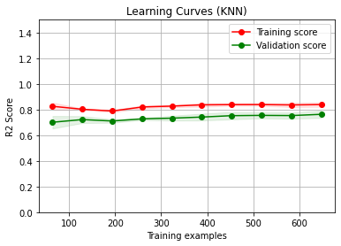

```python
from sklearn.neighbors import KNeighborsRegressor
from sklearn.pipeline import Pipeline
from sklearn.preprocessing import StandardScaler
from sklearn.model_selection import learning_curve
from time import time

start = time()

pipe = Pipeline(steps=[('Standarization', StandardScaler()),
                       ('Regressor', KNeighborsRegressor())])

knn_scores = -cross_val_score(pipe, x_train, y_train, cv=cv, scoring='neg_root_mean_squared_error')

end = time()

print("Scores: {}".format(knn_scores))
print("Mean of Scores: {}".format(knn_scores.mean()))
print("Standard Deviation of Scores: {}".format(knn_scores.std()))
print("Execution time:", end-start, "s")

title = "Learning Curves (KNN)"
plot_learning_curve(pipe, title,
                    x_train, y_train, ylim=(0, 1.5),
                    cv=cv, n_jobs=-1);
```

The RMSE of this model is approximately 0.20. As we can see from the learning curves plot, there is no overfitting, neither underfitting, although the performance could be improved.

## Model2: Decision Trees

```
Scores: [0.21754682 0.22803065 0.2390408 ]
Mean of Scores: 0.2282060904052544
Standard Deviation of Scores: 0.0087757604884593
Execution time: 0.05582404136657715 s
```

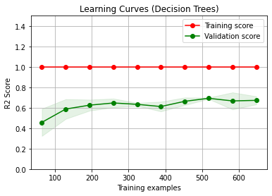

```python
from sklearn import tree
np.random.seed(100459259)

start = time()

dec_tree = tree.DecisionTreeRegressor()
dec_scores = -cross_val_score(dec_tree,
                         x_train, y_train,
                         scoring='neg_root_mean_squared_error',
                         cv = cv)

end = time()

print("Scores: {}".format(dec_scores))
print("Mean of Scores: {}".format(dec_scores.mean()))
print("Standard Deviation of Scores: {}".format(dec_scores.std()))
print("Execution time:", end-start, "s")


title = "Learning Curves (Decision Trees)"
plot_learning_curve(dec_tree, title,
                    x_train, y_train, ylim=(0, 1.5),
                    cv=cv, n_jobs=-1);
```

The RMSE is even larger than in the previous model. Moreover, the learning curves reveal that this model is overfitting, as the model fits perfectly the training data, while achieving very little performance when validating new data.

## Model3: Extra trees

```
Scores: [0.16068368 0.15240514 0.15042954]
Mean of Scores: 0.15450611909135742
Standard deviation of the Scores: 0.004442032501198062
Execution time: 2.5495197772979736 s
```

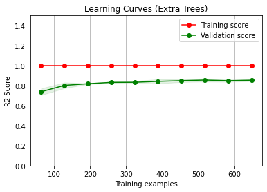

```python
from sklearn.ensemble import ExtraTreesRegressor
np.random.seed(100459259)

start = time()

ext_tree = ExtraTreesRegressor()
ext_scores = -cross_val_score(ext_tree, x_train, y_train, cv=cv, scoring='neg_root_mean_squared_error')

end = time()

print("Scores: {}".format(ext_scores))
print("Mean of Scores: {}".format(ext_scores.mean()))
print("Standard deviation of the Scores: {}".format(ext_scores.std()))
print("Execution time:", end-start, "s")

title = "Learning Curves (Extra Trees)"
plot_learning_curve(ext_tree, title,
                    x_train, y_train, ylim=(0, 1.5),
                    cv=cv, n_jobs=-1);
```

## Model4: Random Forest

```
Scores: [0.14739849 0.16385016 0.15525203]
Mean of Scores: 0.15550022541059716
Standard deviation of the Scores: 0.006718659754763993
Execution time: 3.075514078140259 s
```

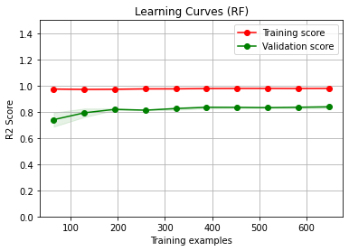

```python
from sklearn.ensemble import RandomForestRegressor
np.random.seed(100459259)

start = time()

rf_reg = RandomForestRegressor()
rf_scores = -cross_val_score(rf_reg, x_train, y_train, cv=cv, scoring='neg_root_mean_squared_error')

end = time()

print("Scores: {}".format(rf_scores))
print("Mean of Scores: {}".format(rf_scores.mean()))
print("Standard deviation of the Scores: {}".format(rf_scores.std()))
print("Execution time:", end-start, "s")

title = "Learning Curves (RF)"
plot_learning_curve(rf_reg, title,
                    x_train, y_train, ylim=(0, 1.5),
                    cv=cv, n_jobs=-1);
```

Although the performance of this model is very similar to the previous one, extra trees gives still better results.

## Model 5: HistGradient Regressor

```
Scores: [0.14700189 0.16370471 0.14770372]
Mean of Scores: 0.15280344148989017
Standard deviation of the Scores: 0.007713680932535797
Execution time: 2.1319127082824707 s
```

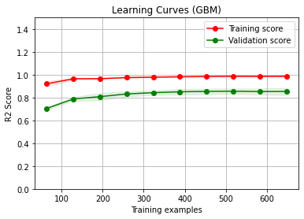

```python
from sklearn.ensemble import HistGradientBoostingRegressor
np.random.seed(100459259)

start = time()

gb_reg = HistGradientBoostingRegressor()
gb_scores = -cross_val_score(gb_reg, x_train, y_train, cv=cv,scoring='neg_root_mean_squared_error')

end = time()

print("Scores: {}".format(gb_scores))
print("Mean of Scores: {}".format(gb_scores.mean()))
print("Standard deviation of the Scores: {}".format(gb_scores.std()))
print("Execution time:", end-start, "s")

title = "Learning Curves (GBM)"
plot_learning_curve(gb_reg, title,
                    x_train, y_train, ylim=(0, 1.5),
                    cv=cv, n_jobs=-1);
```

So far, this is the method that gives the best model. \

The performace of the five implemented methods are gathered in the following table:

| Method | RMSE | Exec. time (s) |
| --- | --- | --- |
| KNN Regressor | 0.1968 | 0.0480 |
| Decision Tree Regressor | 0.2282 | 0.0558 |
| Random Tree Regressor | 0.1555 | 3.0755 |
| Extra Tree Regressor | 0.1545 | 2.5495 |
| HistGradient Regressor | 0.1528 | 2.1319 |

## 3.1.2 Hyperparameter Tuning of KNN using grid search

In this section we will try to improve the performance of the model given by KNN. I order to do so, we implement GridSearchCV. This function finds the hyper-parameter value (among the ones that are proposed) that minimizes the RMSE. This is done by 3-fold cross-validation on the training partition.

```python
from sklearn.model_selection import GridSearchCV
np.random.seed(100459259)

start = time()

param_grid = [{'Regressor__n_neighbors': range(1,30,1)}]

gs_knn = GridSearchCV(pipe,
                 param_grid = param_grid,
                 scoring = 'neg_root_mean_squared_error',
                 cv=cv,
                 n_jobs = -1)

grid_search_knn = gs_knn.fit(x_train, y_train)

end = time()

gs_best_model = -grid_search_knn.best_score_
gs_best_k = grid_search_knn.best_params_
gs_ex_time = end-start

print("Best model: {}".format(gs_best_model))
print("Best k: {}".format(gs_best_k))
print("Execution time:", gs_ex_time, "s")
```

```
Best model: 0.19193289596100704
Best k: {'Regressor__n_neighbors': 8}
Execution time: 0.8218197822570801 s
```

## 3.1.3 Hyperparameter Tuning of Decision Tree Regressor using random search

The goal is to find the best maximum depth and the minimum samples split. Unlike, GridSearchCV, RandomizedSearchCV does not try the whole set of hyper-parameters. Instead, it chooses some values randomly and compares the performance of the resulted models.

```python
from scipy.stats import uniform, expon
from scipy.stats import randint as sp_randint
from sklearn.model_selection import RandomizedSearchCV
np.random.seed(100459259)

start = time()

param_distributions = [{'max_depth': sp_randint(1,50),
                   'min_samples_split': sp_randint(1,50)}]

budget = 20

rs_dec_tree = RandomizedSearchCV(dec_tree,
                 param_distributions = param_distributions,
                 scoring = 'neg_root_mean_squared_error',
                 n_iter = budget,
                 cv=cv,
                 n_jobs = -1)

random_search_dec_tree = rs_dec_tree.fit(x_train, y_train)

end = time()

rs_best_model = -random_search_dec_tree.best_score_
rs_best_parameters = random_search_dec_tree.best_params_
rs_ex_time = end - start

print("Best model: {}".format(rs_best_model))
print("Best Parameters: {}".format(rs_best_parameters))
print("Execution time:", rs_ex_time, "s")
```

```
Best model: 0.1996881213178419
Best Parameters: {'max_depth': 11, 'min_samples_split': 17}
Execution time: 0.5258646011352539 s
```

## 3.1.4 Hyperparameter tuning of Extra Trees using Bayes search

To tune the hyper-parameters of Extra trees (again maximum depth and minimum samples split) we implement a Bayes Search. As before, not all the candidate values are tested, but in this case they are not chosen randomly either. Bayes SearchCV seeks the hyper-parameters that are more likely to improve the performance, ignoring the values that it considers are not worthy to try.

```python
from skopt import BayesSearchCV
from skopt.space import Integer
np.random.seed(100459259)

start = time()

param_grid = {'max_depth': Integer(2, 20),
              'min_samples_split': Integer(2, 20)}

budget = 20
bs_ext_tree = BayesSearchCV(ext_tree,
                            param_grid,
                            scoring = 'neg_root_mean_squared_error',
                            cv = cv,
                            n_jobs = -1, verbose = 1,
                            n_iter = budget)

bayes_search_ext_tree = bs_ext_tree.fit(x_train, y_train)

end = time()

best_model = -bayes_search_ext_tree.best_score_
best_parameters = bayes_search_ext_tree.best_params_

print("Best model: {}".format(best_model))
print("Best Parameters: {}".format(best_parameters))
print("Execution time:", end-start, "s")
```

[output not shown]

```
Fitting 3 folds for each of 1 candidates, totalling 3 fits
Fitting 3 folds for each of 1 candidates, totalling 3 fits
Fitting 3 folds for each of 1 candidates, totalling 3 fits
Fitting 3 folds for each of 1 candidates, totalling 3 fits
```

```
Fitting 3 folds for each of 1 candidates, totalling 3 fits
Best model: 0.1461576115910371
Best Parameters: OrderedDict([('max_depth', 12), ('min_samples_split', 2)])
Execution time: 36.50195264816284 s
```

## 3.1.5 Hyperparameter Tuning Gradient Descent

In this section we will use the Optuna package. Optuna also implements by default a Bayes search to do hyper-parameter tuning. However, the coding is different from what we have seen so far. It is necessary to define the objective function, that is, the function we want to optimize. In each iteration, this function is called and evaluated with the new set of suggested hyper-parameters.

```python
def objective(trial):

  max_depth = trial.suggest_int('max_depth', 2, 16)
  learning_rate = trial.suggest_uniform('learning_rate', 0, 1)
  max_iter = trial.suggest_int('max_iter',10,600)

  clf = HistGradientBoostingRegressor(max_depth = max_depth,
                                      learning_rate = learning_rate,
                                      max_iter = max_iter)
  scores = -cross_val_score(clf, x_train, y_train,
                            scoring = 'neg_root_mean_squared_error',
                            n_jobs = -1, cv = cv)

  inner_rmse = scores.mean()

  return inner_rmse

np.random.seed(100459259)

start = time()

budget = 20

study = optuna.create_study(direction = 'minimize')
study.optimize(objective, n_trials = budget)

end = time()

best_model = study.best_value
best_parameters = study.best_params

print("Best model: {}".format(best_model))
print("Best Parameters: {}".format(best_parameters))
print("Execution time:", end-start, "s")
```

```
[I 2022-01-08 08:01:11,311] A new study created in memory with name: no-name-29a35334-3328-4008-baf4-338600eba163
[I 2022-01-08 08:01:12,308] Trial 0 finished with value: 0.2130934385884118 and parameters: {'max_depth': 6, 'learning_rate': 0.9067128139642723, 'max_iter': 100}. Best is trial 0 with value: 0.2130934385884118.
[I 2022-01-08 08:01:17,988] Trial 1 finished with value: 0.14738162558938037 and parameters: {'max_depth': 10, 'learning_rate': 0.052384217812351586, 'max_iter': 483}. Best is trial 1 with value: 0.14738162558938037.
[I 2022-01-08 08:01:22,050] Trial 2 finished with value: 0.15140620250310463 and parameters: {'max_depth': 5, 'learning_rate': 0.208711267045269, 'max_iter': 595}. Best is trial 1 with value: 0.14738162558938037.
[I 2022-01-08 08:01:22,314] Trial 3 finished with value: 0.18690940799520198 and parameters: {'max_depth': 7, 'learning_rate': 0.767926511620015, 'max_iter': 20}. Best is trial 1 with value: 0.14738162558938037.
[I 2022-01-08 08:01:29,192] Trial 4 finished with value: 0.1449794117894521 and parameters: {'max_depth': 11, 'learning_rate': 0.04021525744620269, 'max_iter': 532}. Best is trial 4 with value: 0.1449794117894521.
[I 2022-01-08 08:01:35,977] Trial 5 finished with value: 0.15995132065442352 and parameters: {'max_depth': 12, 'learning_rate': 0.4248215046777173, 'max_iter': 491}. Best is trial 4 with value: 0.1449794117894521.
[I 2022-01-08 08:01:39,958] Trial 6 finished with value: 0.193350525216761 and parameters: {'max_depth': 6, 'learning_rate': 0.8425079166800017, 'max_iter': 446}. Best is trial 4 with value: 0.1449794117894521.
[I 2022-01-08 08:01:43,159] Trial 7 finished with value: 0.1804274289588236 and parameters: {'max_depth': 4, 'learning_rate': 0.7256873764878279, 'max_iter': 574}. Best is trial 4 with value: 0.1449794117894521.
[I 2022-01-08 08:01:47,027] Trial 8 finished with value: 0.16365782306767004 and parameters: {'max_depth': 9, 'learning_rate': 0.3221540112910206, 'max_iter': 357}. Best is trial 4 with value: 0.1449794117894521.
[I 2022-01-08 08:01:51,422] Trial 9 finished with value: 0.167816242099884 and parameters: {'max_depth': 8, 'learning_rate': 0.5836896557871962, 'max_iter': 400}. Best is trial 4 with value: 0.1449794117894521.
[I 2022-01-08 08:01:55,255] Trial 10 finished with value: 0.16603897724714395 and parameters: {'max_depth': 16, 'learning_rate': 0.008625999476686873, 'max_iter': 234}. Best is trial 4 with value: 0.1449794117894521.
[I 2022-01-08 08:01:59,283] Trial 11 finished with value: 0.14703315237030545 and parameters: {'max_depth': 13, 'learning_rate': 0.03506698012930965, 'max_iter': 266}. Best is trial 4 with value: 0.1449794117894521.
[I 2022-01-08 08:02:03,205] Trial 12 finished with value: 0.15004610683942934 and parameters: {'max_depth': 13, 'learning_rate': 0.18842763755927133, 'max_iter': 268}. Best is trial 4 with value: 0.1449794117894521.
[I 2022-01-08 08:02:06,176] Trial 13 finished with value: 0.14729134420317122 and parameters: {'max_depth': 14, 'learning_rate': 0.17047089003953436, 'max_iter': 184}. Best is trial 4 with value: 0.1449794117894521.
[I 2022-01-08 08:02:10,515] Trial 14 finished with value: 0.15736690276179832 and parameters: {'max_depth': 11, 'learning_rate': 0.3764907684488534, 'max_iter': 324}. Best is trial 4 with value: 0.1449794117894521.
[I 2022-01-08 08:02:11,005] Trial 15 finished with value: 0.16084491296185982 and parameters: {'max_depth': 2, 'learning_rate': 0.5434551327657765, 'max_iter': 166}. Best is trial 4 with value: 0.1449794117894521.
[I 2022-01-08 08:02:17,296] Trial 16 finished with value: 0.14868934837436032 and parameters: {'max_depth': 15, 'learning_rate': 0.09284802137345438, 'max_iter': 395}. Best is trial 4 with value: 0.1449794117894521.
[I 2022-01-08 08:02:21,263] Trial 17 finished with value: 0.15495582700544852 and parameters: {'max_depth': 12, 'learning_rate': 0.2364664574842258, 'max_iter': 287}. Best is trial 4 with value: 0.1449794117894521.
[I 2022-01-08 08:02:24,577] Trial 18 finished with value: 0.3398170208963757 and parameters: {'max_depth': 10, 'learning_rate': 0.0010164255143760084, 'max_iter': 202}. Best is trial 4 with value: 0.1449794117894521.
[I 2022-01-08 08:02:32,743] Trial 19 finished with value: 0.1598569589798921 and parameters: {'max_depth': 14, 'learning_rate': 0.29695384745562825, 'max_iter': 528}. Best is trial 4 with value: 0.1449794117894521.
```

```
Best model: 0.1449794117894521
Best Parameters: {'max_depth': 11, 'learning_rate': 0.04021525744620269, 'max_iter': 532}
Execution time: 81.43442630767822 s
```

## 3.1.6 Optuna research

### Pruning algorithms with OPTUNA

Pruning algorithms allow terminating the learning process prematurely based on the result of previous trials. Pruning mechanism in general works in two phases: \ (1) It periodically monitors the intermediate objective values. \ (2) It terminates the trial that does not meet the predefined condition. \

In addition to the median stopping rule, which is the pruner that has been used below, Optuna also supports algorithms such as Successive Halving and Hyperband , but the basic ideas remain largely the same.

In order to divide the training process in several steps, we need to implement the partial_fit function. This function does not train the model with the whole dataset at once, but adding incremental chunks of data instead. This is how we can detect unpromising trials and stop the training before all the chunks are added. However, the partial_fit function can just be implemented to some algorithms that can learn incrementally. This is the reason we have selected stochastic gradient descent regressor for this exercise. Hence, the hyper-parameter we need to optimize in this case is alpha. As our aim is to just to show how the pruning algorithm works, we will use reduced training and testing sets.\

We see that the code is very similar to the one in the above-mentioned section. Nevertheless, we find the following changes: \ 1) Inside the objective function we perform a loop of 20 iterations corresponding to the number of steps the training process is going to take. \ 2) Inside this loop we evaluate the model resulted from each step and we save the value of the error (score) of each step (trial.report). \ 3) The pruner is called at the end of each step to inspect whether the trial should be pruned or not. \ 4) The pruner is specified in the study session. \

In the output the pruned trials appear explicitly. \

```python
from sklearn.linear_model import SGDRegressor
x_train_2 = x_train[0:300,:]
y_train_2 = y_train[0:300]
x_test_2 = x_train[300:400,:]
y_test_2 = y_train[300:400]

def objective_2(trial):

  alpha = trial.suggest_float('alpha', 1e-5, 1e-1, log=True)

  for step in range(20):

    clf = SGDRegressor(alpha = alpha)

    clf.partial_fit(x_train_2, y_train_2)

    # Report intermediate objective value
    intermediate_value = -clf.score(x_test_2, y_test_2)
    trial.report(intermediate_value, step)

    # Handle pruning based on the intermediate value.
    if trial.should_prune():
      raise optuna.TrialPruned()

  return intermediate_value

budget = 20
np.random.seed(100459259)

study_2 = optuna.create_study(direction = 'minimize', pruner=optuna.pruners.MedianPruner())
study_2.optimize(objective_2, n_trials = budget)
```

```
[I 2022-01-08 08:03:27,751] A new study created in memory with name: no-name-0d27dfbb-9e70-440f-804a-bf878c4afe03
[I 2022-01-08 08:03:27,778] Trial 0 finished with value: 1.0711722743322264e+35 and parameters: {'alpha': 0.00011727604000216051}. Best is trial 0 with value: 1.0711722743322264e+35.
[I 2022-01-08 08:03:27,802] Trial 1 finished with value: 5.201037287135799e+35 and parameters: {'alpha': 2.2442091658470777e-05}. Best is trial 0 with value: 1.0711722743322264e+35.
[I 2022-01-08 08:03:27,827] Trial 2 finished with value: 2.5187724529259493e+35 and parameters: {'alpha': 0.009018866686404295}. Best is trial 0 with value: 1.0711722743322264e+35.
[I 2022-01-08 08:03:27,851] Trial 3 finished with value: 1.5442516802836584e+35 and parameters: {'alpha': 0.0028967214901671596}. Best is trial 0 with value: 1.0711722743322264e+35.
[I 2022-01-08 08:03:27,876] Trial 4 finished with value: 4.408281691981193e+34 and parameters: {'alpha': 0.0041757217075157095}. Best is trial 4 with value: 4.408281691981193e+34.
[I 2022-01-08 08:03:27,882] Trial 5 pruned.
[I 2022-01-08 08:03:27,887] Trial 6 pruned.
[I 2022-01-08 08:03:27,893] Trial 7 pruned.
[I 2022-01-08 08:03:27,925] Trial 8 finished with value: 1.7751285073989787e+34 and parameters: {'alpha': 0.061930944221623575}. Best is trial 8 with value: 1.7751285073989787e+34.
[I 2022-01-08 08:03:27,954] Trial 9 finished with value: 6.791708780989554e+35 and parameters: {'alpha': 0.019520476352792866}. Best is trial 8 with value: 1.7751285073989787e+34.
[I 2022-01-08 08:03:27,963] Trial 10 pruned.
[I 2022-01-08 08:03:27,969] Trial 11 pruned.
[I 2022-01-08 08:03:27,979] Trial 12 pruned.
[I 2022-01-08 08:03:27,989] Trial 13 pruned.
[I 2022-01-08 08:03:27,994] Trial 14 pruned.
[I 2022-01-08 08:03:28,004] Trial 15 pruned.
[I 2022-01-08 08:03:28,017] Trial 16 pruned.
[I 2022-01-08 08:03:28,049] Trial 17 finished with value: 2.5322676997758953e+35 and parameters: {'alpha': 0.00015280843548636362}. Best is trial 8 with value: 1.7751285073989787e+34.
[I 2022-01-08 08:03:28,092] Trial 18 finished with value: 3.790984352780305e+35 and parameters: {'alpha': 0.006948387474737001}. Best is trial 8 with value: 1.7751285073989787e+34.
[I 2022-01-08 08:03:28,101] Trial 19 pruned.
```

### Graphycal analysis with optuna

In first place, we will use optuna.visualization.plot_optimization_history. Its output is a plot of the value of the objective function for each trial (blue dots). It also shows the current best value as a red line. This red line changes its position each time a new trial finds a better combination of hyperparameters. \

```python
fig = optuna.visualization.plot_optimization_history(study)
fig.show()
```

[interactive chart not shown]

Optuna also allows to study the importance of each parameter for the estimation of the objective function. Such importances can be visualized executing optuna.visualization.plot_param_importances.

```python
fig = optuna.visualization.plot_param_importances(study)
fig.show()
```

[interactive chart not shown]

From this plot we can conclude that the maximum depth is the least important hyper-parameter, while the learning rate is the most important one. This means that spending computational resources on searching the optimal learning rate would be much more efficient and would give similar results than searching for the whole optimal hyper-parameter space. \

Now we wil implement optuna.visualization.plot_slice. This function plots the value of the objective function againts the value of each hyper-parameter in each trial. This function allows to introduce a list of parameters to visualize, but by default all parameters are shown.

```python
fig = optuna.visualization.plot_slice(study)
fig.show()
```

[interactive chart not shown]

By using optuna.visualization.matplotlib.plot_parallel_coordinate it is possible to get a parallel coodinates plot (PCP). PCP draws coordinates in parallel axes and connects them with straight lines. The variables (hyper-parameters and objective function) are drawn into the horizontal axis and its values are mapped onto the vertical axis. Each line represents a trial.\ This graph helps to visualize if the election of any hyper-parameters is somehow skewed .

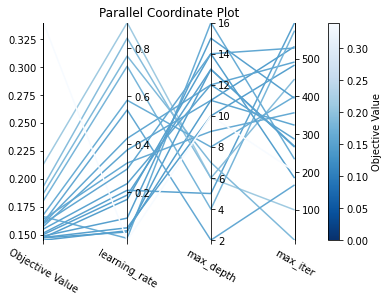

```python
optuna.visualization.matplotlib.plot_parallel_coordinate(study)
```

Finally, we will make use of optuna.visualization.plot_contour. This command deploys parameter relationship as contour plot. The lighter areas show the values of the pair of hyper-parameter that minimizes the objective function.

```python
fig = optuna.visualization.plot_contour(study)
fig.show()
```

[interactive chart not shown]

```python
fig = optuna.visualization.plot_intermediate_values(study_2)
fig.show()
```

[interactive chart not shown]

## 3.1.7 Models comparison

The results from hyper-parameter tuning are summed up in the following table:

| Method | Best hyper-parameters | New RMSE | Old RMSE | New exec. time (s) | Old exec.time (s) |
| --- | --- | --- | --- | --- | --- |
| KNN Regressor | Neighbours: 8 | 0.1919 | 0.1968 | 0.8218 | 0.0480 |
| Decision Tree Regressor | Max depth: 11, Min samples split: 17 | 0.1996 | 0.2282 | 0.5258 | 0.0558 |
| Extra tree Regressor | Max depth: 12, Min samples split: 2 | 0.1461 | 0.1545 | 36.5019 | 2.5495 |
| HistGradient Regressor | Max depth: 11, Learning rate: 0.04, Max iter: 532 | 0.1449 | 0.1528 | 81.4344 | 2.1319 |

## 3.1.8 CASH with extra trees and gradient boosting

As an exercise, we will use optuna in order to perform hyper-parameter tunning, including also the model as a parameter of the search space.

```python
def objective_cash(trial):

  method = trial.suggest_categorical('method',['ext_tree','gb_reg'])
  if (method == 'ext_tree'):
    max_depth = trial.suggest_int('max_depth', 2, 20),
    min_samples_split = trial.suggest_int('min_samples_split', 2, 20)

    clf = ExtraTreesRegressor(max_depth = max_depth,
                              min_samples_split = min_samples_split)

  else:
    max_depth = trial.suggest_int('max_depth', 2, 16)
    learning_rate = trial.suggest_uniform('learning_rate', 0, 1)
    max_iter = trial.suggest_int('max_iter',10,600)

    clf = HistGradientBoostingRegressor(max_depth = max_depth,
                                        learning_rate = learning_rate,
                                        max_iter = max_iter)

  scores = -cross_val_score(clf, x_train, y_train,
                            scoring = 'neg_root_mean_squared_error',
                            n_jobs = -1, cv = cv)

  inner_rmse = scores.mean()

  return inner_rmse

np.random.seed(100459259)

budget = 40

study = optuna.create_study(direction = 'minimize')
study.optimize(objective_cash, n_trials = budget)

best_model = study.best_value
best_parameters = study.best_params

print("Best model: {}".format(best_model))
print("Best Parameters: {}".format(best_parameters))
```

[output not shown]

[output cut: 1156 more lines]

[output not shown]

```
Best model: 0.1354060906302897
Best Parameters: {'method': 'gb_reg', 'max_depth': 2, 'learning_rate': 0.09914427256278313, 'max_iter': 186}
```

The model selected is histgradient regressor. This is not surprising, as we have seen before that the performance of this model is slightly better than the extra tree regressor. However, the selected hyper-parameters do not coincide with the ones we had previously found. Also, this new set results in a better performace.

# 3.2 Model evaluation

The histgradient boosting regressor and extra trees performed quite well, therefore, we will evaluate these two models in test sample in order to see their performance in test dataset. The reason to evaluate these two well-performed models in test sample is to find out whether these models also perform good in test sample or not.

After comparing two methods in 3.1.8 histgradient has been chosen , therefore, we will use the hyper-parameters of CASH for histgradient boosting regressor and hyper-parameters given by Bayes search for extra trees. Afterwards, we will compare the results and choose the best model.

```
Root Mean Squared Error (RMSE): 0.1256
```

```
                                 OLS Regression Results
=======================================================================================
Dep. Variable:                      y   R-squared (uncentered):                   1.000
Model:                            OLS   Adj. R-squared (uncentered):              1.000
Method:                 Least Squares   F-statistic:                          4.470e+06
Date:                Sat, 08 Jan 2022   Prob (F-statistic):                        0.00
Time:                        08:20:57   Log-Likelihood:                          319.45
No. Observations:                 487   AIC:                                     -636.9
Df Residuals:                     486   BIC:                                     -632.7
Df Model:                           1
Covariance Type:            nonrobust
==============================================================================
                 coef    std err          t      P>|t|      [0.025      0.975]
------------------------------------------------------------------------------
x1             0.9997      0.000   2114.172      0.000       0.999       1.001
==============================================================================
Omnibus:                      149.107   Durbin-Watson:                   2.010
Prob(Omnibus):                  0.000   Jarque-Bera (JB):             1942.981
Skew:                           0.934   Prob(JB):                         0.00
Kurtosis:                      12.605   Cond. No.                         1.00
==============================================================================

Warnings:
[1] Standard Errors assume that the covariance matrix of the errors is correctly specified.
```

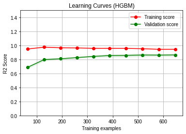

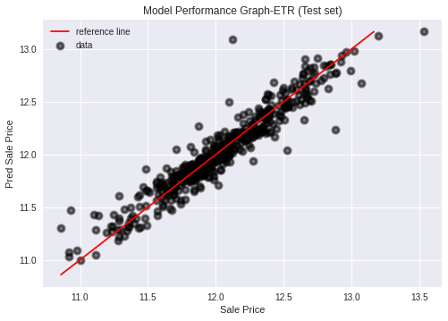

```python
# Training with the training partition and evaluation with the test partition.
np.random.seed(100459259)

model_hgbm = HistGradientBoostingRegressor(max_depth = 2,
                                      learning_rate = 0.09914427256278313,
                                      max_iter = 186)

model_hgbm.fit(x_train, y_train)
pred_hgbm = model_hgbm.predict(x_test)

title = "Learning Curves (HGBM)"
cv = cv
plot_learning_curve(model_hgbm, title,
                    x_train, y_train, ylim=(0, 1.5),
                    cv=cv, n_jobs=-1);

# Evaluation of the model
mse  = mean_squared_error(y_test, pred_hgbm)
rmse = np.sqrt(mse)
print('Root Mean Squared Error (RMSE): %.4f' % rmse)

import statsmodels.api as sm
model_gb_ols = sm.OLS(model_hgbm.predict(x_test), y_test)
print(model_gb_ols.fit().summary())


# Scatter Plot

lineStart = y_test.min()
lineEnd = model_hgbm.predict(x_test).max()

plt.style.use('seaborn')
plt.figure()
plt.scatter(y_test, pred_hgbm, color = 'k', alpha=0.5, linewidths=3, label='data')
plt.plot([lineStart, lineEnd], [lineStart, lineEnd], 'k-', color = 'r', label='reference line')
# plt.xlim(lineStart, lineEnd)
# plt.ylim(lineStart, lineEnd)
plt.title("Model Performance Graph-ETR (Test set)")
plt.xlabel("Sale Price")
plt.ylabel("Pred Sale Price")
plt.legend()
plt.show()
```

```
Root Mean Squared Error (RMSE): 0.1453
                                 OLS Regression Results
=======================================================================================
Dep. Variable:                      y   R-squared (uncentered):                   1.000
Model:                            OLS   Adj. R-squared (uncentered):              1.000
Method:                 Least Squares   F-statistic:                          3.339e+06
Date:                Sat, 08 Jan 2022   Prob (F-statistic):                        0.00
Time:                        08:21:27   Log-Likelihood:                          248.23
No. Observations:                 487   AIC:                                     -494.5
Df Residuals:                     486   BIC:                                     -490.3
Df Model:                           1
Covariance Type:            nonrobust
==============================================================================
                 coef    std err          t      P>|t|      [0.025      0.975]
------------------------------------------------------------------------------
x1             1.0001      0.001   1827.277      0.000       0.999       1.001
==============================================================================
Omnibus:                      152.506   Durbin-Watson:                   1.968
Prob(Omnibus):                  0.000   Jarque-Bera (JB):             1403.177
Skew:                           1.079   Prob(JB):                    2.01e-305
Kurtosis:                      11.031   Cond. No.                         1.00
==============================================================================

Warnings:
[1] Standard Errors assume that the covariance matrix of the errors is correctly specified.
```

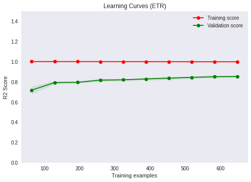

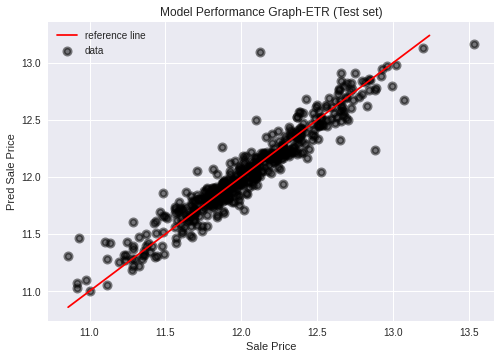

```python
# Training with the training partition and evaluation with the test partition.
np.random.seed(100459259)

model_extree =ExtraTreesRegressor(max_depth = 12,
                                min_samples_split = 2)

model_extree.fit(x_train, y_train)
pred_extree = model_extree.predict(x_test)

title = "Learning Curves (ETR)"
cv = cv
plot_learning_curve(model_extree, title,
                    x_train, y_train, ylim=(0, 1.5),
                    cv=cv, n_jobs=-1);

# Evaluation of the model
mse  = mean_squared_error(y_test, pred_extree)
rmse = np.sqrt(mse)
print('Root Mean Squared Error (RMSE): %.4f' % rmse)

import statsmodels.api as sm
model_gb_ols = sm.OLS(model_extree.predict(x_test), y_test)
print(model_gb_ols.fit().summary())


# Scatter Plot

lineStart = y_test.min()
lineEnd = model_extree.predict(x_test).max()

plt.style.use('seaborn')
plt.figure()
plt.scatter(y_test, pred_hgbm, color = 'k', alpha=0.5, linewidths=3, label='data')
plt.plot([lineStart, lineEnd], [lineStart, lineEnd], 'k-', color = 'r', label='reference line')
# plt.xlim(lineStart, lineEnd)
# plt.ylim(lineStart, lineEnd)
plt.title("Model Performance Graph-ETR (Test set)")
plt.xlabel("Sale Price")
plt.ylabel("Pred Sale Price")
plt.legend()
plt.show()
```

To conclude, Hist Gradient Boosting model performed better than Extra Trees with very few difference. The test-rmse has been found 0.1256 for HGBM and 0.1453 for Extra Trees. This result makes clear that we should use Hist Gradient Boosting model to make the final model.

# 3.3 Final model

In this part, the sale price will be predicted for X_comp sample. Hist Gradient Boosting model will be used to predict.

```python
# Training the model with the whole dataset.

model_hgbm.fit(X, y)
y_comp = model_hgbm.predict(X_comp)

# Transformation of log(price) to actual price.

SalePrice = np.exp(y_comp)
Id = list(range(1461,2920))
pred_df_hgbm = pd.DataFrame({"Id": Id, "SalePrice": SalePrice})
pred_df_hgbm
```

|  | Id | SalePrice |
| --- | --- | --- |
| 0 | 1461 | 109989.428271 |
| 1 | 1462 | 156560.414811 |
| 2 | 1463 | 180616.704672 |
| 3 | 1464 | 180830.693754 |
| 4 | 1465 | 193483.884263 |
| ... | ... | ... |
| 1454 | 2915 | 78350.262744 |
| 1455 | 2916 | 83577.498496 |
| 1456 | 2917 | 171925.379315 |
| 1457 | 2918 | 120925.954380 |
| 1458 | 2919 | 238361.851598 |

1459 rows × 2 columns

We save the final results in .csv.

```python
from google.colab import drive
drive.mount('/drive')
```

```python
pred_df_hgbm.to_csv('/drive/My Drive/Predictions_HGBM.csv', index=False)
```

# 3.4 Extra - Halving Optimization Method

## 3.4.1 Halving Grid Search and Halving Random Search Explanation

### **Halving Grid Search Method**

Halving Grid Search is an optimized version of Grid Search hyperparameter optimization. Halving Grid Search searches over a given list of hyperparameters using a sequential bisection approach. The search strategy begins evaluating all candidates on a small sample of data and iteratively selects the best candidates using increasingly larger numbers of samples. HalvingGridSearchCV, which is inside of the Scikit-Learn library, will be used to imply this method for KNN model.

### **Halving Random Search Method**

Halving Randomized Search uses the same sequential halving approach and it is even more optimized than Grid Search. Unlike Halving Grid Search, it is not trained on all hyper-parameter combinations, but instead picks a random set of hyper-parameter combinations. HalvingRandomizedSeachCV, which is also inside of the Scikit-Learn library, will be used to imply this method for decision tree regressor model.

## 3.4.2 Implementing Halving Grid to KNN

**Parameters definition:**

- factor: the proportion of candidates that are selected for each subsequent iteration. For example, factor=3 means that only one third of the candidates are selected.
- resource: 'n_samples' defines the resource that increases with each iteration. By default, the resource is the number of samples.
- min_resources: The minimum amount of resource that any candidate is allowed to use for a given iteration.

**Attributes definition:**

```python
import time
from sklearn.experimental import enable_halving_search_cv
from sklearn.model_selection import HalvingGridSearchCV
from sklearn.model_selection import cross_val_score, KFold

rn = np.random.seed(100459259)
cv = KFold(n_splits=3, shuffle=False, random_state=rn)

FACTOR = 2
MAX_RESOURCE_DIVISOR = 4

n_samples = x_train.shape[0]
param_grid = [{'Regressor__n_neighbors': range(1,30,1)}]

start_time = time.time()

halving_grid_search_knn = HalvingGridSearchCV(pipe,resource='n_samples',
                                                min_resources=n_samples//MAX_RESOURCE_DIVISOR,
                                                factor=FACTOR,
                                                param_grid = param_grid,
                                                scoring = 'neg_root_mean_squared_error',
                                                cv=cv, n_jobs = -1).fit(x_train, y_train)

end_time  = time.time()

halving_best_model = -halving_grid_search_knn.best_score_
halving_best_k = halving_grid_search_knn.best_params_
resources = halving_grid_search_knn.n_resources_
iterations = halving_grid_search_knn.n_iterations_
candidates = halving_grid_search_knn.n_candidates_
hl_ex_time = end_time - start_time

print("Best CV Score: {}".format(halving_best_model))
print("Best k: {}".format(halving_best_k))
print("Resources: {}".format(resources))
print("Iterations: {}".format(iterations))
print("n_canditates: {}".format(candidates))
print("execution time: {}".format(round(hl_ex_time,4)))
results = pd.DataFrame(halving_grid_search_knn.cv_results_)
```

```
Best CV Score: 0.18710573758786322
Best k: {'Regressor__n_neighbors': 9}
Resources: [243, 486, 972]
Iterations: 3
n_canditates: [29, 15, 8]
execution time: 1.3717
```

```python
results.head()
```

|  | iter | n_resources | mean_fit_time | std_fit_time | mean_score_time | std_score_time | param_Regressor__n_neighbors | params | split0_test_score | split1_test_score | split2_test_score | mean_test_score | std_test_score | rank_test_score | split0_train_score | split1_train_score | split2_train_score | mean_train_score | std_train_score |
| --- | --- | --- | --- | --- | --- | --- | --- | --- | --- | --- | --- | --- | --- | --- | --- | --- | --- | --- | --- |
| 0 | 0 | 243 | 0.003168 | 0.001411 | 0.001755 | 0.000305 | 1 | {'Regressor__n_neighbors': 1} | -0.209411 | -0.246014 | -0.261846 | -0.239090 | 0.021959 | 45 | -0.000000 | -0.000000 | -0.000000 | 0.000000 | 0.000000 |
| 1 | 0 | 243 | 0.002686 | 0.000446 | 0.001710 | 0.000153 | 2 | {'Regressor__n_neighbors': 2} | -0.193596 | -0.212691 | -0.260143 | -0.222143 | 0.027978 | 33 | -0.113563 | -0.115403 | -0.143552 | -0.124173 | 0.013724 |
| 2 | 0 | 243 | 0.002107 | 0.000508 | 0.001845 | 0.000362 | 3 | {'Regressor__n_neighbors': 3} | -0.199602 | -0.200762 | -0.242313 | -0.214225 | 0.019866 | 23 | -0.127867 | -0.151207 | -0.172497 | -0.150524 | 0.018226 |
| 3 | 0 | 243 | 0.004077 | 0.002848 | 0.002095 | 0.000166 | 4 | {'Regressor__n_neighbors': 4} | -0.204452 | -0.194982 | -0.220181 | -0.206538 | 0.010393 | 9 | -0.137830 | -0.165328 | -0.180925 | -0.161361 | 0.017816 |
| 4 | 0 | 243 | 0.002030 | 0.000097 | 0.004152 | 0.002142 | 5 | {'Regressor__n_neighbors': 5} | -0.206853 | -0.210919 | -0.214288 | -0.210686 | 0.003040 | 12 | -0.141614 | -0.171847 | -0.193627 | -0.169029 | 0.021328 |

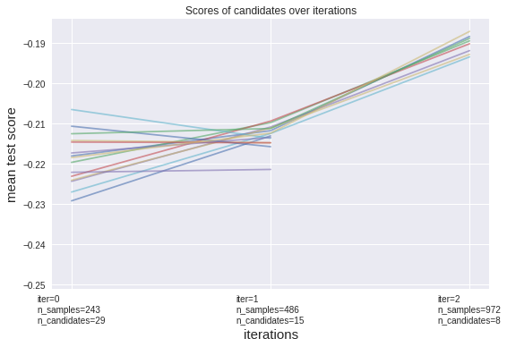

```python
results["params_str"] = results.params.apply(str)
results.drop_duplicates(subset=("params_str", "iter"), inplace=True)
mean_scores = results.pivot(index="iter", columns="params_str", values="mean_test_score")

ax = mean_scores.plot(legend=False, alpha=0.6)

labels = [f"iter={i}\nn_samples={resources[i]}\nn_candidates={candidates[i]}"
          for i in range(iterations)]

ax.set_xticks(range(iterations))
ax.set_xticklabels(labels,  multialignment="left")
ax.set_title("Scores of candidates over iterations")
ax.set_ylabel("mean test score", fontsize=15)
ax.set_xlabel("iterations", fontsize=15)
plt.tight_layout()
plt.show()
```

### **Comparison between Grid Search CV and Halving Grid Search Methods**

- The execution time is a little longer for HalvingGridSearchCV compared to GridSearchCV. Generally, HalvingGridSearchCV optimizes the execution time, however for KNN not many parameters have been tried. Maybe because of that, the execution times are quite similar.
- On the other hand, HalvingGridSearchCV selects a different number of neighbours, but the RMSE is reduced compared to GridSearchCV. HalvingGridSearchCV has found better CV result than GridSearchCV.

**Both CV results are shown below:**

```python
Grid = pd.DataFrame(gs_best_k, index=[0]).assign(RMSE=gs_best_model, Method="Grid Search" ,Execution_Time = gs_ex_time)
Halving = pd.DataFrame(halving_best_k, index=[0]).assign(RMSE=halving_best_model, Method="Halving Grid Search",Execution_Time=hl_ex_time)
Grid_Halving_Comparison = Grid.append(Halving, ignore_index=True)

Grid_Halving_Comparison.index = Grid_Halving_Comparison['Method']
Grid_Halving_Comparison.drop('Method', axis=1, inplace=True)
Grid_Halving_Comparison.index.name = ''
Grid_Halving_Comparison
```

|  | Regressor__n_neighbors | RMSE | Execution_Time |
| --- | --- | --- | --- |
| Grid Search | 8 | 0.191933 | 0.821820 |
| Halving Grid Search | 9 | 0.187106 | 1.371696 |

## 3.4.3 Implementing Halving Random Search Method to Decision Tree Regressor Model

```python
from scipy.stats import uniform, expon
from scipy.stats import randint as sp_randint
from sklearn.experimental import enable_halving_search_cv
from sklearn.model_selection import HalvingRandomSearchCV
import time

param_distributions = [{'max_depth': sp_randint(1,50),
                   'min_samples_split': sp_randint(1,50)}]
FACTOR = 2
MAX_RESOURCE_DIVISOR = 4

n_samples = x_train.shape[0]

rn = np.random.seed(100459259)

start_time = time.time()

rs_dec_tree = HalvingRandomSearchCV(dec_tree,
                                    resource='n_samples',
                                    min_resources= n_samples//MAX_RESOURCE_DIVISOR,
                                    factor = FACTOR,
                                    param_distributions = param_distributions,
                                    scoring = 'neg_root_mean_squared_error',
                                    cv=3,
                                    n_jobs = -1,
                                    random_state = rn).fit(x_train, y_train)


end_time = time.time()

hl_rs_best_model = -rs_dec_tree.best_score_
hl_rs_best_parameters = rs_dec_tree.best_params_
hl_rs_resources = rs_dec_tree.n_resources_
hl_rs_iterations = rs_dec_tree.n_iterations_
hl_rs_candidates = rs_dec_tree.n_candidates_
hl_rs_ex_time = end_time - start_time

print("Best CV Score: {}".format(hl_rs_best_model))
print("Best k: {}".format(hl_rs_best_parameters))
print("Resources: {}".format(hl_rs_resources))
print("Iterations: {}".format(hl_rs_iterations))
print("n_canditates: {}".format(hl_rs_candidates))
print("execution time: {}".format(round(hl_rs_ex_time,4)))
hl_rs_results = pd.DataFrame(rs_dec_tree.cv_results_)
```

```
Best CV Score: 0.2174088629777469
Best k: {'max_depth': 31, 'min_samples_split': 32}
Resources: [243, 486, 972]
Iterations: 3
n_canditates: [4, 2, 1]
execution time: 0.1689
```

```python
hl_rs_results
```

|  | iter | n_resources | mean_fit_time | std_fit_time | mean_score_time | std_score_time | param_max_depth | param_min_samples_split | params | split0_test_score | split1_test_score | split2_test_score | mean_test_score | std_test_score | rank_test_score | split0_train_score | split1_train_score | split2_train_score | mean_train_score | std_train_score |
| --- | --- | --- | --- | --- | --- | --- | --- | --- | --- | --- | --- | --- | --- | --- | --- | --- | --- | --- | --- | --- |
| 0 | 0 | 243 | 0.003419 | 0.000108 | 0.000887 | 0.000126 | 27 | 21 | {'max_depth': 27, 'min_samples_split': 21} | -0.251116 | -0.301962 | -0.295848 | -0.282975 | 0.022666 | 6 | -0.117589 | -0.139457 | -0.146530 | -0.134525 | 0.012319 |
| 1 | 0 | 243 | 0.003005 | 0.000516 | 0.002024 | 0.001833 | 7 | 27 | {'max_depth': 7, 'min_samples_split': 27} | -0.267964 | -0.304760 | -0.263099 | -0.278608 | 0.018599 | 5 | -0.142748 | -0.150692 | -0.192447 | -0.161962 | 0.021799 |
| 2 | 0 | 243 | 0.002597 | 0.000078 | 0.000696 | 0.000016 | 31 | 32 | {'max_depth': 31, 'min_samples_split': 32} | -0.271619 | -0.301626 | -0.259657 | -0.277634 | 0.017654 | 4 | -0.158552 | -0.166397 | -0.196453 | -0.173801 | 0.016335 |
| 3 | 0 | 243 | 0.002973 | 0.000587 | 0.000605 | 0.000201 | 7 | 14 | {'max_depth': 7, 'min_samples_split': 14} | -0.257489 | -0.301076 | -0.304719 | -0.287761 | 0.021457 | 7 | -0.103240 | -0.122244 | -0.138685 | -0.121390 | 0.014483 |
| 4 | 1 | 486 | 0.005545 | 0.000072 | 0.000844 | 0.000055 | 7 | 27 | {'max_depth': 7, 'min_samples_split': 27} | -0.234354 | -0.196066 | -0.198190 | -0.209537 | 0.017570 | 2 | -0.130952 | -0.126561 | -0.130924 | -0.129479 | 0.002063 |
| 5 | 1 | 486 | 0.006690 | 0.001349 | 0.000983 | 0.000242 | 31 | 32 | {'max_depth': 31, 'min_samples_split': 32} | -0.233772 | -0.193404 | -0.195873 | -0.207683 | 0.018475 | 1 | -0.134993 | -0.124898 | -0.157380 | -0.139090 | 0.013574 |
| 6 | 2 | 972 | 0.011117 | 0.001601 | 0.000918 | 0.000147 | 31 | 32 | {'max_depth': 31, 'min_samples_split': 32} | -0.220697 | -0.215651 | -0.215878 | -0.217409 | 0.002327 | 3 | -0.126795 | -0.129520 | -0.134566 | -0.130293 | 0.003219 |

### **Comparison between Random Search CV and Halving Random Search Methods**

**Both CV results are shown below:**

```python
RandomSearch = pd.DataFrame(rs_best_parameters, index=[0]).assign(RMSE=rs_best_model, Method="Random Search" ,Execution_Time = rs_ex_time)
Halving_RS = pd.DataFrame(hl_rs_best_parameters, index=[0]).assign(RMSE=hl_rs_best_model, Method="Halving Random Search",Execution_Time=hl_rs_ex_time)
RS_Halving_Comparison = RandomSearch.append(Halving_RS, ignore_index=True)

RS_Halving_Comparison.index = RS_Halving_Comparison['Method']
RS_Halving_Comparison.drop('Method', axis=1, inplace=True)
RS_Halving_Comparison.index.name = ''
RS_Halving_Comparison
```

|  | max_depth | min_samples_split | RMSE | Execution_Time |
| --- | --- | --- | --- | --- |
| Random Search | 11 | 17 | 0.199688 | 0.525865 |
| Halving Random Search | 31 | 32 | 0.217409 | 0.168911 |

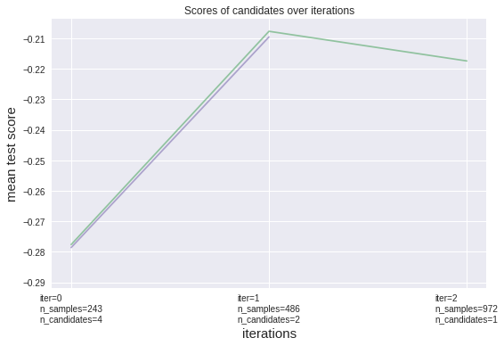

```python
hl_rs_results["params_str"] = hl_rs_results.params.apply(str)
hl_rs_results.drop_duplicates(subset=("params_str", "iter"), inplace=True)
mean_scores = hl_rs_results.pivot(index="iter", columns="params_str", values="mean_test_score")

ax = mean_scores.plot(legend=False, alpha=0.6)

labels = [f"iter={i}\nn_samples={hl_rs_resources[i]}\nn_candidates={hl_rs_candidates[i]}"
          for i in range(hl_rs_iterations)]

ax.set_xticks(range(hl_rs_iterations))
ax.set_xticklabels(labels,  multialignment="left")
ax.set_title("Scores of candidates over iterations")
ax.set_ylabel("mean test score", fontsize=15)
ax.set_xlabel("iterations", fontsize=15)
plt.tight_layout()
plt.show()
```

## 3.4.3 Using XGBoost

XGBoost is an optimized Gradient Boosting algorithm through parallel processing with threads, tree-pruning, handling missing values and regularization to avoid overfitting/bias.

Before using XGBModel, data is called again because in previous section, we have done the prediction and found y_comp. After calling the data again from the same excel file, all x_train, y_train, x_test and y_test transformed to sparse matrises.

```python
import xgboost as xgb

data2 = data.values

## (X,y) contains the available data for model training, hyper-parameter tuning, model selection, and model evaluation
X = data2[0:1460,:-1]
y = data2[0:1460,-1]

## Competition data (will be used after training)
X_comp = data2[1460:,:-1]
y_comp = data2[1460:,-1] ## there is no data for now on

## splitting the data
from sklearn.model_selection import train_test_split

np.random.seed(100459259)

x_train, x_test, y_train, y_test = train_test_split(X,y,
                                                    test_size=1/3,
                                                    random_state=0)

## feature names
data_nontarget  = data.iloc[:,0:79]
features = data_nontarget.columns

## creating sparse and dense matrises for XGBModel

import scipy
from scipy.sparse import csr_matrix

# full data
X_csr = csr_matrix(X)
dense_full = xgb.DMatrix(X_csr, label = y,feature_names=features)

sparse_train = scipy.sparse.csr_matrix(x_train)
label_train  = y_train
dense_train  = xgb.DMatrix(sparse_train, label=label_train,feature_names=features)

sparse_test = scipy.sparse.csr_matrix(x_test)
label_test  = y_test
dense_test  = xgb.DMatrix(sparse_test, label=label_test, feature_names=features)

## XGBModel estimator

from xgboost import XGBRegressor

estimator = XGBRegressor(objective= 'reg:squarederror',
                         nthread=4,
                         seed=100459259
                        )
```

### Hyper Parameter Tuning

#### Hyper Parameter Tuning with Optuna

```python
def objective(trial):

  max_depth = trial.suggest_int('max_depth', 2, 12)
  learning_rate = trial.suggest_uniform('learning_rate', 0, 1)
  gamma = trial.suggest_uniform('gamma', 0, 1)
  n_estimators = trial.suggest_int('n_estimators',60,300)

  estimator_optuna = XGBRegressor(objective = "reg:squarederror",
                              max_depth = max_depth,
                              learning_rate = learning_rate,
                              gamma = gamma,
                              n_estimators = n_estimators,
                              booster = 'dart',
                              seed=100459259)
  scores = -cross_val_score(estimator, sparse_train,label_train,
                            scoring = 'neg_root_mean_squared_error',
                            n_jobs = -1, cv = cv)

  inner_rmse = scores.mean()

  return inner_rmse


np.random.seed(100459259)


budget = 20

study = optuna.create_study(direction = 'minimize')
study.optimize(objective, n_trials = budget)



best_model = study.best_value
best_parameters = study.best_params

print("Best model: {}".format(best_model))
print("Best Parameters: {}".format(best_parameters))
print("Execution time:", end-start, "s")
```

```
[I 2022-01-08 08:25:48,373] A new study created in memory with name: no-name-531b0d2e-6b16-4427-a8ce-c65799389d9e
[I 2022-01-08 08:25:49,496] Trial 0 finished with value: 0.1362920035418675 and parameters: {'max_depth': 7, 'learning_rate': 0.7434376700388832, 'gamma': 0.3746205790870919, 'n_estimators': 233}. Best is trial 0 with value: 0.1362920035418675.
[I 2022-01-08 08:25:50,145] Trial 1 finished with value: 0.1362920035418675 and parameters: {'max_depth': 8, 'learning_rate': 0.7371528679130374, 'gamma': 0.6621770070334536, 'n_estimators': 99}. Best is trial 0 with value: 0.1362920035418675.
[I 2022-01-08 08:25:50,765] Trial 2 finished with value: 0.1362920035418675 and parameters: {'max_depth': 5, 'learning_rate': 0.7550214389901565, 'gamma': 0.03265835790944227, 'n_estimators': 163}. Best is trial 0 with value: 0.1362920035418675.
[I 2022-01-08 08:25:51,425] Trial 3 finished with value: 0.1362920035418675 and parameters: {'max_depth': 9, 'learning_rate': 0.3661186669360663, 'gamma': 0.9129228225551977, 'n_estimators': 96}. Best is trial 0 with value: 0.1362920035418675.
[I 2022-01-08 08:25:52,045] Trial 4 finished with value: 0.1362920035418675 and parameters: {'max_depth': 10, 'learning_rate': 0.6195131152351411, 'gamma': 0.9276381383740137, 'n_estimators': 142}. Best is trial 0 with value: 0.1362920035418675.
[I 2022-01-08 08:25:52,686] Trial 5 finished with value: 0.1362920035418675 and parameters: {'max_depth': 2, 'learning_rate': 0.9662328226030785, 'gamma': 0.6358714755479733, 'n_estimators': 237}. Best is trial 0 with value: 0.1362920035418675.
[I 2022-01-08 08:25:53,333] Trial 6 finished with value: 0.1362920035418675 and parameters: {'max_depth': 5, 'learning_rate': 0.09863070142672292, 'gamma': 0.6510384026550435, 'n_estimators': 112}. Best is trial 0 with value: 0.1362920035418675.
[I 2022-01-08 08:25:53,947] Trial 7 finished with value: 0.1362920035418675 and parameters: {'max_depth': 11, 'learning_rate': 0.0993217281569102, 'gamma': 0.14367403032602855, 'n_estimators': 273}. Best is trial 0 with value: 0.1362920035418675.
[I 2022-01-08 08:25:54,607] Trial 8 finished with value: 0.1362920035418675 and parameters: {'max_depth': 2, 'learning_rate': 0.2181419641405682, 'gamma': 0.788688846263083, 'n_estimators': 293}. Best is trial 0 with value: 0.1362920035418675.
[I 2022-01-08 08:25:55,231] Trial 9 finished with value: 0.1362920035418675 and parameters: {'max_depth': 10, 'learning_rate': 0.889301889478675, 'gamma': 0.2284032073753376, 'n_estimators': 255}. Best is trial 0 with value: 0.1362920035418675.
[I 2022-01-08 08:25:55,882] Trial 10 finished with value: 0.1362920035418675 and parameters: {'max_depth': 6, 'learning_rate': 0.479793172849532, 'gamma': 0.34248356715003275, 'n_estimators': 207}. Best is trial 0 with value: 0.1362920035418675.
[I 2022-01-08 08:25:56,521] Trial 11 finished with value: 0.1362920035418675 and parameters: {'max_depth': 8, 'learning_rate': 0.6819588761688307, 'gamma': 0.4225059241771, 'n_estimators': 64}. Best is trial 0 with value: 0.1362920035418675.
[I 2022-01-08 08:25:57,153] Trial 12 finished with value: 0.1362920035418675 and parameters: {'max_depth': 7, 'learning_rate': 0.8148129937298401, 'gamma': 0.5752226541303322, 'n_estimators': 211}. Best is trial 0 with value: 0.1362920035418675.
[I 2022-01-08 08:25:57,804] Trial 13 finished with value: 0.1362920035418675 and parameters: {'max_depth': 12, 'learning_rate': 0.5980712630109944, 'gamma': 0.46438400508343614, 'n_estimators': 182}. Best is trial 0 with value: 0.1362920035418675.
[I 2022-01-08 08:25:58,453] Trial 14 finished with value: 0.1362920035418675 and parameters: {'max_depth': 7, 'learning_rate': 0.4769901822954647, 'gamma': 0.3279673374347861, 'n_estimators': 121}. Best is trial 0 with value: 0.1362920035418675.
[I 2022-01-08 08:25:59,082] Trial 15 finished with value: 0.1362920035418675 and parameters: {'max_depth': 4, 'learning_rate': 0.98682425175041, 'gamma': 0.7652783357420145, 'n_estimators': 79}. Best is trial 0 with value: 0.1362920035418675.
[I 2022-01-08 08:25:59,721] Trial 16 finished with value: 0.1362920035418675 and parameters: {'max_depth': 8, 'learning_rate': 0.7790494529074492, 'gamma': 0.5365167404503672, 'n_estimators': 217}. Best is trial 0 with value: 0.1362920035418675.
[I 2022-01-08 08:26:00,350] Trial 17 finished with value: 0.1362920035418675 and parameters: {'max_depth': 6, 'learning_rate': 0.44412328714239957, 'gamma': 0.27764517244828096, 'n_estimators': 134}. Best is trial 0 with value: 0.1362920035418675.
[I 2022-01-08 08:26:01,004] Trial 18 finished with value: 0.1362920035418675 and parameters: {'max_depth': 3, 'learning_rate': 0.9767191834727778, 'gamma': 0.7867227977557961, 'n_estimators': 67}. Best is trial 0 with value: 0.1362920035418675.
[I 2022-01-08 08:26:01,679] Trial 19 finished with value: 0.1362920035418675 and parameters: {'max_depth': 9, 'learning_rate': 0.8410670101312083, 'gamma': 0.5215862633670187, 'n_estimators': 224}. Best is trial 0 with value: 0.1362920035418675.
```

```
Best model: 0.1362920035418675
Best Parameters: {'max_depth': 7, 'learning_rate': 0.7434376700388832, 'gamma': 0.3746205790870919, 'n_estimators': 233}
Execution time: 81.43442630767822 s
```

In Optuna, the best model has been found with 0.1362 RMSE score with following best hyper parameters. We will test the selected model in model evaluation section.

#### Hyper Parameter Tuning with Halving Random Search for XGBModel

```python
from time import time

rn = np.random.seed(100459259)

from sklearn.experimental import enable_halving_search_cv
from sklearn.model_selection import HalvingRandomSearchCV

FACTOR = 2
MAX_RESOURCE_DIVISOR = 4

n_samples = sparse_train.shape[0]


grid_param_xgb = [{'max_depth': range(2, 12, 1),
                   'n_estimators': range(60, 300, 40),
                   'learning_rate': [0.05,0.01,0.1,0.3],
                   'gamma': [0,0.3,0.6,1],
                   'booster': ['gbtree', 'dart']
                 }]


start_time = time()

halving_grid_search_xgb = HalvingRandomSearchCV(estimator,resource='n_samples',
                                                min_resources=n_samples//MAX_RESOURCE_DIVISOR,
                                                factor=FACTOR,
                                                param_distributions = grid_param_xgb,
                                                scoring = 'neg_root_mean_squared_error', cv=3,
                                                n_jobs = -1,  random_state = rn).fit(sparse_train,label_train)

end_time  = time()

halving_xgb_best_model = -halving_grid_search_xgb.best_score_
halving_xgb_best_params = halving_grid_search_xgb.best_params_
hl_xgb_resources = halving_grid_search_xgb.n_resources_
hl_xgb_iterations = halving_grid_search_xgb.n_iterations_
hl_xgb_candidates = halving_grid_search_xgb.n_candidates_
hl_xgb_ex_time = end_time - start_time

print("Best CV Score: {}".format(halving_xgb_best_model))
print("Best parameters: {}".format(halving_xgb_best_params))
print("Resources: {}".format(hl_xgb_resources))
print("Iterations: {}".format(hl_xgb_iterations))
print("n_canditates: {}".format(hl_xgb_candidates))
print("execution time: {}".format(round(hl_xgb_ex_time,4)))
results_xgb = pd.DataFrame(halving_grid_search_xgb.cv_results_)
```

```
Best CV Score: 0.1376363226860785
Best parameters: {'n_estimators': 140, 'max_depth': 6, 'learning_rate': 0.05, 'gamma': 0, 'booster': 'dart'}
Resources: [243, 486, 972]
Iterations: 3
n_canditates: [4, 2, 1]
execution time: 8.1326
```

In Halving RandomSearchCV, the best model has been found with 0.1376 RMSE which is larger than the RMSE achieved by Optuna. We will test both selected models in model evaluation section to see which one is best for the test sample.

*Note: In halving RandomSearchSV, the hyper-parameters grid were not given randomly as in Optuna.*

### XGBModel Evaluation

```python
## model evaluation

xgb_params = {'booster': 'dart',
              'gamma': 0.9597641683283693,
              'learning_rate': 0.04397193211151251,
              'max_depth': 7,
              'n_estimators': 260,
              'objective':'reg:squarederror'

              }

xgb_params['eval_metric'] = "rmse"
evallist = [(dense_test, 'eval')]
num_round = 1000

bst_optuna = xgb.train(xgb_params, dense_train, num_round, evallist, early_stopping_rounds=10)
```

[output not shown]

#### XGBModel Evaluation with Halving Random Search Hyper-parameters

```python
## model evaluation

xgb_params = {'booster': 'dart',
              'gamma': 0,
              'learning_rate': 0.05,
              'max_depth': 6,
              'n_estimators': 140
              }


xgb_params['eval_metric'] = "rmse"
evallist = [(dense_test, 'eval')]
num_round = 1000

bst = xgb.train(xgb_params, dense_train, num_round, evallist, early_stopping_rounds=10)

# best model: [254]	eval-rmse:0.123379
```

[output not shown]

By using RandomSearchCV for hyper parameter tuning of XGBModel, we got higher RMSE score for training sample compared to Optuna. However, the test-RMSE has been found lower than Optuna's test-RMSE score.

Even though the train-RMSE score was higher than in the model using Optuna, the selected model from HalvingRandomSearchCV worked better in test sample. Test-rmse has been calculated 0.1233. Therefore, for prediction, the model with less eval-RMSE will be used.

### Feature Importance with Weight and Gain Values

In XGBoost, it is possible to visualize each feature importance with its weight, which is useful to distinguish the relevant attributes.

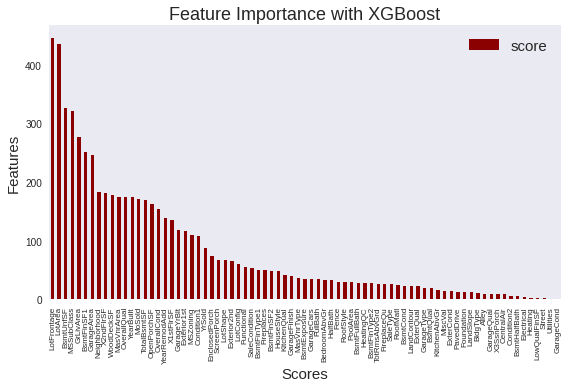

```
No handles with labels found to put in legend.
```

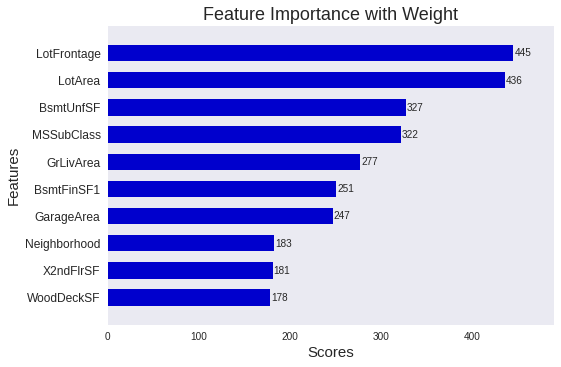

```python
feature_important = bst.get_score(importance_type='weight')
keys = list(feature_important.keys())
values = list(feature_important.values())

## visual 1
data_xgb = pd.DataFrame(data=values, index=keys, columns=["score"]).sort_values(by = "score", ascending=False)
p1 = data_xgb.plot(kind='bar',legend=False, alpha=1, color = "darkred", grid = False)
p1.tick_params(axis='y', labelsize=10)
p1.tick_params(axis='x', labelsize=8)
p1.set_title("Feature Importance with XGBoost", fontsize=18)
p1.set_ylabel("Features", fontsize=15)
p1.set_xlabel("Scores", fontsize=15)
p1.legend(fontsize=15)
plt.tight_layout()
plt.show()

## visual 2

p2 = xgb.plot_importance(bst, importance_type='weight', height = 0.6, show_values=True, max_num_features= 10, grid=False, color= "mediumblue")
p2.tick_params(axis='y', labelsize=12)
p2.set_title('Feature Importance with Weight', fontsize=18)
p2.set_ylabel("Features", fontsize=15)
p2.set_xlabel("Scores", fontsize=15)
p2.legend(fontsize=15)
plt.show()
```

### Plotting Test and Train Samples

```
Root Mean Squared Error (RMSE): 0.1234
```

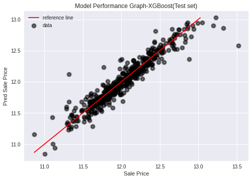

```python
## Prediction with the best model
ypred = bst.predict(dense_test, ntree_limit=bst.best_ntree_limit)
ypred_train = bst.predict(dense_train, ntree_limit=bst.best_ntree_limit)

#evolution of the test sample
from sklearn.metrics import mean_squared_error

mse  = mean_squared_error(label_test, ypred)
rmse = np.sqrt(mse)

print('Root Mean Squared Error (RMSE): %.4f' % rmse)

# Scatter Plot
x =  label_test
y =  ypred

lineStart = label_test.min()
lineEnd = ypred.max()

plt.style.use('seaborn')
plt.figure()
plt.scatter(x, y, color = 'k', alpha=0.5, linewidths=3, label='data')
plt.plot([lineStart, lineEnd], [lineStart, lineEnd], 'k-', color = 'r', label='reference line')
plt.title("Model Performance Graph-XGBoost(Test set)")
plt.xlabel("Sale Price")
plt.ylabel("Pred Sale Price")
plt.legend()
plt.show()
```

### Final Model - Prediction

```python
## model evaluation

sparse_final = scipy.sparse.csr_matrix(X_comp)
label_final  = y_comp
dense_final  = xgb.DMatrix(sparse_final, label=label_final, feature_names=features)

label_final = bst.predict(dense_final, ntree_limit=bst.best_ntree_limit)

SalePrice_xgb = np.exp(label_final)


Id = list(range(1461,2920))
pred_df_xgb = pd.DataFrame({"Id": Id, "SalePrice": SalePrice_xgb})
pred_df_xgb
```

|  | Id | SalePrice |
| --- | --- | --- |
| 0 | 1461 | 117575.296875 |
| 1 | 1462 | 164858.234375 |
| 2 | 1463 | 184130.093750 |
| 3 | 1464 | 192030.968750 |
| 4 | 1465 | 185332.312500 |
| ... | ... | ... |
| 1454 | 2915 | 77856.210938 |
| 1455 | 2916 | 81660.031250 |
| 1456 | 2917 | 157924.671875 |
| 1457 | 2918 | 110760.406250 |
| 1458 | 2919 | 229340.750000 |

1459 rows × 2 columns

```python
from google.colab import drive
drive.mount('/drive')
```

```python
pred_df_xgb.to_csv('/drive/My Drive/Predictions_XGB.csv',index=False)
```

### Conclusions

For improvement, XGBoost model has been used to predict the Sale Price. Best hyper-parameters for XGBoost model have been tried. These have been found by HalvingRandomSearchCV and Optuna. After doing model evaluation in test sample, XGBoost model has been executed with the best hyper-parameter given by Halving random seach CV. The test-RMSE score calculated is 0.1234 which is quite similar but smaller than the solution found with histgradient boosting model (0.1256).

# References

Optuna documentation \ https://optuna.readthedocs.io/ \ https://scikit-learn.org/0.15/modules/scaling_strategies.html \ https://medium.com/optuna/an-introduction-to-the-implementation-of-optuna-a-hyperparameter-optimization-framework \ https://scikit-learn.org/stable/modules/grid_search.html#searching-for-optimal-parameters-with-successive-halving \ https://scikit-learn.org/stable/modules/generated/sklearn.model_selection.